# 3rd Research Question

Groupmates:Dowland,Roy,Winston

2025-05-13

```r
library(dplyr)
```

```r
library(readr)
library(ggplot2)
library(tidyr)
library(purrr)
library(stringr)
```

## 1 Abstract:

In our project, we will be investigating the relationship between public sentiment toward the topic of immigration and the enforcement of U.S. immigration policy throughout the time frame from 2004 to 2024. As we use Google Trends as data for the Public interest in immigration and U.S Customs and Border Protection records of Apprehensions from 2020 to 2023, we will be examining how attention towards immigration has changed over time across different regions in the United States.

## 2 Introduction:

Immigration has always been a politically and socially charged topic in the United States, particularly around presidential election time, for decades. More recently, public debate around immigration policy, border patrol, and deportations has been increasing driven by media reporting, political speech, and changing national agendas. Consequently, it is more important now, with the increasing public concern provided through social media and the Web, to understand the relationship between public attitudes and the enforcement of policy. In our research, the public sentiment can be represent by the Google Trends data, which indicates the frequency with which topics related to immigration are searched online. Although the data itself is not an actual measure of opinions, but it can still indicate what types of topic is trending in the public. Meanwhile, U.S. Customs and Border Protection continually posts records on border apprehensions, expulsions, and inadmissibles, giving the public a measure of policy enforcement toward immigration.

Research Question I’ll Be investigating: How does public sentiment toward immigration vary across different U.S. regions, particularly during presidential election cycles?

This research question is important to us as it helps us understand how public attention and concern about immigration can differ depending on where people live in the United State. By using both the Google trend’s data and Apprehension data, we can understand how much people are looking into the topic of immigration even if they aren’t saying it out loud directly.

## 3 Data Sources

### 3.1 Sources of Data

[Google Trend](https://trends.google.com/trends/)

The second data set I used is from US Custom and Border Protection as it gives us the apprehension data in the United State coverage from 2020-2023 which shows the recent government enforcement.

[US Custom and Border](https://www.cbp.gov/document/stats/nationwide-encounters)

The US Custom and Border Protection data set is collected by me and the Google Trend’s data is collected by my group mate Dowland.

### 3.2 Data Usage Permission

Both data set is freely accessible to the public that have access to the internet. There are no restriction to the data set. However for the Google Trend’s data, you’ll have to put the keyword in for example: “Immigration”, to be able to search for the Query Incidence Score for the topic you’re interested in.

### 3.3 Data Supporting Research Question

For my research question, I had chosen the Google Trend’s data set as it provide a measurable indicator of public interest in the topic of immigration across the time frame and regions we’re investigating in. Since our research question focus on how public sentiment may influence immigration policy, the google trend’s data set will help us capture all the attention and concern of public in different election cycles.

On the other side, border Encounter data set (2020-2023) offers concrete data on immigration enforcement actions, such as apprehensions, expulsions and inadmissible cases. These action represent the policy outcomes we aim to evaluate in response to public sentiment. Together, these dataset will support my research question by allowing me to examine whether public interest are associate with changes in federal immigration enforcement.

## 4. Data

### 4.1 Google Trends Data

```r
google <- read.csv("../../data_cleaned/google_trends/summarized.csv")
head(google,3)
```

```
##   X                                      DMA daterange query_incidence
## 1 1                     Yuma AZ-El Centro CA     04-08             100
## 2 2                  Miami-Ft. Lauderdale FL     04-08              84
## 3 3 Harlingen-Weslaco-Brownsville-McAllen TX     04-08              74
```

```r
str(google)
```

```
## 'data.frame':    2730 obs. of  4 variables:
##  $ X              : int  1 2 3 4 5 6 7 8 9 10 ...
##  $ DMA            : chr  "Yuma AZ-El Centro CA" "Miami-Ft. Lauderdale FL" "Harlingen-Weslaco-Brownsville-McAllen TX" "Alpena MI" ...
##  $ daterange      : chr  "04-08" "04-08" "04-08" "04-08" ...
##  $ query_incidence: int  100 84 74 73 72 71 71 69 67 67 ...
```

```r
colSums(is.na(google))
```

```
##               X             DMA       daterange query_incidence
##               0               0               0               7
```

When observing if there are any NA values in the Google trends data set, we can notice that there are 7 NA values in the Query_Incidence score variables which will be removed for data cleaning.

```r
google <- google %>%
  filter(!is.na(query_incidence))
colSums(is.na(google))
```

```
##               X             DMA       daterange query_incidence
##               0               0               0               0
```

### 4.2 Border Encounters Data

```r
apprehension <- read.csv("../../data_cleaned/sbo-encounters-fy20-fy23.csv")
head(apprehension,3)
```

```
##   Fiscal.Year Month.Grouping Month..abbv.                  Component
## 1        2020           FYTD          OCT Office of Field Operations
## 2        2020           FYTD          OCT Office of Field Operations
## 3        2020           FYTD          OCT Office of Field Operations
##          Demographic Citizenship.Grouping Title.of.Authority Encounter.Type
## 1 Accompanied Minors          El Salvador            Title 8  Inadmissibles
## 2 Accompanied Minors            Guatemala            Title 8  Inadmissibles
## 3 Accompanied Minors               Mexico            Title 8  Inadmissibles
##   Encounter.Count
## 1               2
## 2               1
## 3              91
```

```r
str(apprehension)
```

```
## 'data.frame':    2409 obs. of  9 variables:
##  $ Fiscal.Year         : int  2020 2020 2020 2020 2020 2020 2020 2020 2020 2020 ...
##  $ Month.Grouping      : chr  "FYTD" "FYTD" "FYTD" "FYTD" ...
##  $ Month..abbv.        : chr  "OCT" "OCT" "OCT" "OCT" ...
##  $ Component           : chr  "Office of Field Operations" "Office of Field Operations" "Office of Field Operations" "Office of Field Operations" ...
##  $ Demographic         : chr  "Accompanied Minors" "Accompanied Minors" "Accompanied Minors" "Accompanied Minors" ...
##  $ Citizenship.Grouping: chr  "El Salvador" "Guatemala" "Mexico" "Other" ...
##  $ Title.of.Authority  : chr  "Title 8" "Title 8" "Title 8" "Title 8" ...
##  $ Encounter.Type      : chr  "Inadmissibles" "Inadmissibles" "Inadmissibles" "Inadmissibles" ...
##  $ Encounter.Count     : int  2 1 91 8 38 80 159 2937 784 39 ...
```

```r
colSums(is.na(apprehension))
```

```
##          Fiscal.Year       Month.Grouping         Month..abbv.
##                    0                    0                    0
##            Component          Demographic Citizenship.Grouping
##                    0                    0                    0
##   Title.of.Authority       Encounter.Type      Encounter.Count
##                    0                    0                    0
```

By looking at the data below, there are no na value in the Apprehension data.

## 5 Method

### 5.1 Data Cleaninig for the Google Trends Data

```r
locales <- c("metro")
timeframes <- c("04-08", "08-12", "12-16", "16-20", "20-24", "16-17", "17-18", "18-19", "19-20", "20-21", "21-22", "22-23", "23-24")

read_imm_reg_timeframe <- function(region, daterange) {
  path <- str_c(
    "./data_cleaned/google_trends/query_immigration_",
    region,
    "_",
    daterange,
    "-election.csv"
  )

  df <- read.csv(path)

  df %>%
    mutate("daterange" = daterange) %>%
    (\(df) df %>% rename(query_incidence = names(df)[2]))() %>%
    select(DMA, daterange, query_incidence)
}
```

- The Google Trends Data was cleaned by our groupmates Dowland which we all used the summarized.csv data as the main dataset for our google trend’s data from 2004-2024
- The most relevent variables that will be answering our research question will be the date range and the Query Incidence scores as we’re able to observe the change of public interest over time through different election cycle in the United State.

#### Data Wrangling for Google Trends

```r
google <- google %>%
  mutate(Fiscal.Year = case_when(
    daterange == "04-08" ~ 2008,
    daterange == "08-12" ~ 2012,
    daterange == "12-16" ~ 2016,
    daterange == "16-20" ~ 2020,
    daterange == "20-24" ~ 2024,
    TRUE ~ NA_real_
  ))

google_summary <- google %>%
  group_by(Fiscal.Year) %>%
  summarise(avg_query_incidence = mean(query_incidence, na.rm = TRUE))
```

```r
google_merge <- google %>%
  mutate(Fiscal.Year = case_when(
    daterange == "16-20" ~ 2020,
    daterange == "20-21" ~ 2021,
    daterange == "21-22" ~ 2022,
    daterange == "22-23" ~ 2023,
    TRUE ~ NA_real_
  ))
google_mergesummary <- google_merge %>%
  group_by(Fiscal.Year) %>%
  summarise(avg_query_incidence = mean(query_incidence, na.rm = TRUE))
```

In this steps, I transformed the Google Trends data by mapping each date range to a single fiscal year to align it with policy enforcement records. Then, I summarized public sentiment by calculating the average query incidence per year. Similarly, I grouped border enforcement data by fiscal year and encounter type, pivoting it into a wide format which is easier for comparison. These wrangling steps will allowed us to analyze both data sets on a same time scale, which would support our research in investigating the relationship between immigration sentiment and policy response.

### 5.2 Data Cleaning for Border Encounters Data

```r
# Summarize enforcement data by year and type
app_summary <- apprehension %>%
  group_by(Fiscal.Year, Encounter.Type) %>%
  summarise(total = sum(Encounter.Count, na.rm = TRUE), .groups = "drop") %>%
  pivot_wider(names_from = Encounter.Type, values_from = total)
```

This is the data cleaning step where I organized the border encounter’s data set. I grouped the data set by Fiscal.Year and Encounter.Type to compute the total number of encounters for each type per year by summing encounter.count while removing any missing values. After that, I reshaped the data into a wide form so Encounter.Type became its own column with corresponding total count.

### 5.3 Merging Data

```r
combined_df <- left_join(google_mergesummary, app_summary, by = "Fiscal.Year")
head(combined_df,5)
```

```
## # A tibble: 5 × 5
##   Fiscal.Year avg_query_incidence Apprehensions Expulsions Inadmissibles
##         <dbl>               <dbl>         <int>      <int>         <int>
## 1        2020                43.5        203608     204787         49693
## 2        2021                40.3        618986    1063526         52174
## 3        2022                32.4       1152352    1079507        147085
## 4        2023                31.4       1496067     564380        415222
## 5          NA                43.9            NA         NA            NA
```

To analyze the relationship between public sentiment and immigration enforcement, I merged the two data set into one, where I merge Google Trends data and border encounter data using a left_join() on the shared variable Fiscal.Year as the google trends data set has been wrangled from date range to Fiscal Year. The merged summary data allowed me to combine the average search interest from Google Trends with the total number of apprehensions, expulsions, and inadmissible for each corresponding year.

## 6 Results

### 6.1. Plot 1: Public Sentiment Over Time

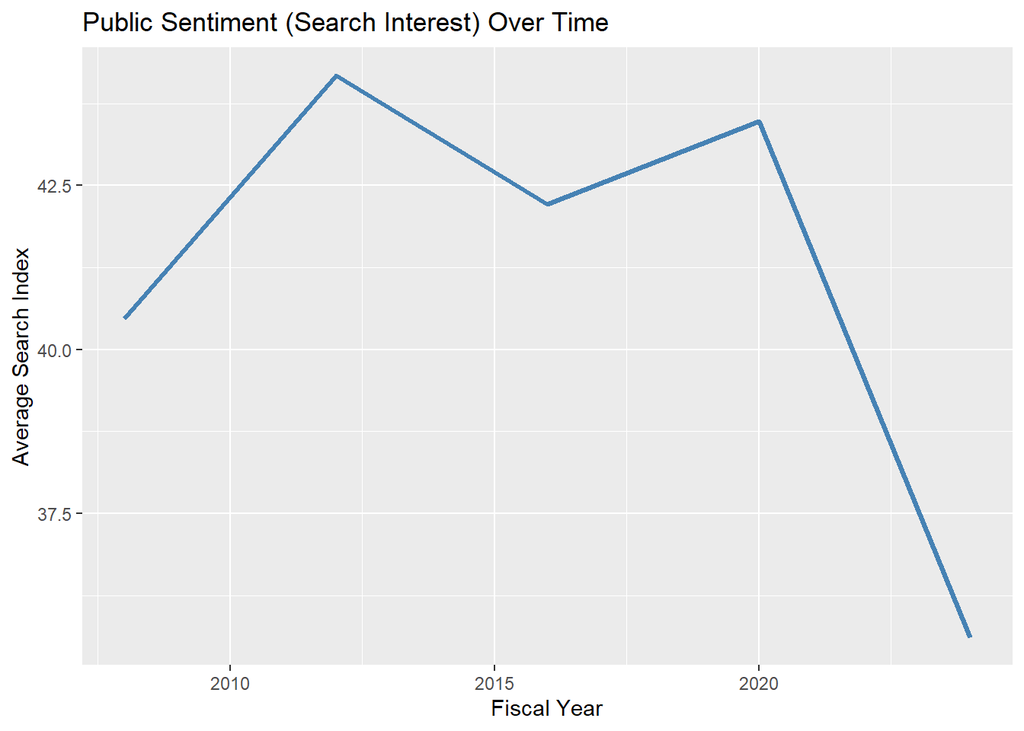

```r
ggplot(google_summary, aes(x = Fiscal.Year, y = avg_query_incidence)) +
  geom_line(color = "steelblue", size = 1.2) +
  labs(title = "Public Sentiment (Search Interest) Over Time",
       x = "Fiscal Year", y = "Average Search Index")
```

This diagram shows the average Google Search interest in immigration across different years. From the data, we can observe that public attention peaked around 2012 and 2020, which aligns with the major election cycle of Obama and Trump. The trends have highlighted how immigration has become an important topic during the politically charged period but lost attention afterward. In addition, after 2020, we can observe a decline in the public’s interest in the topic of immigration which can likely be cause becuase of the increase of public attention on Covid 19.

### 6.2. Plot 2: Immigration Enforcement Over Time

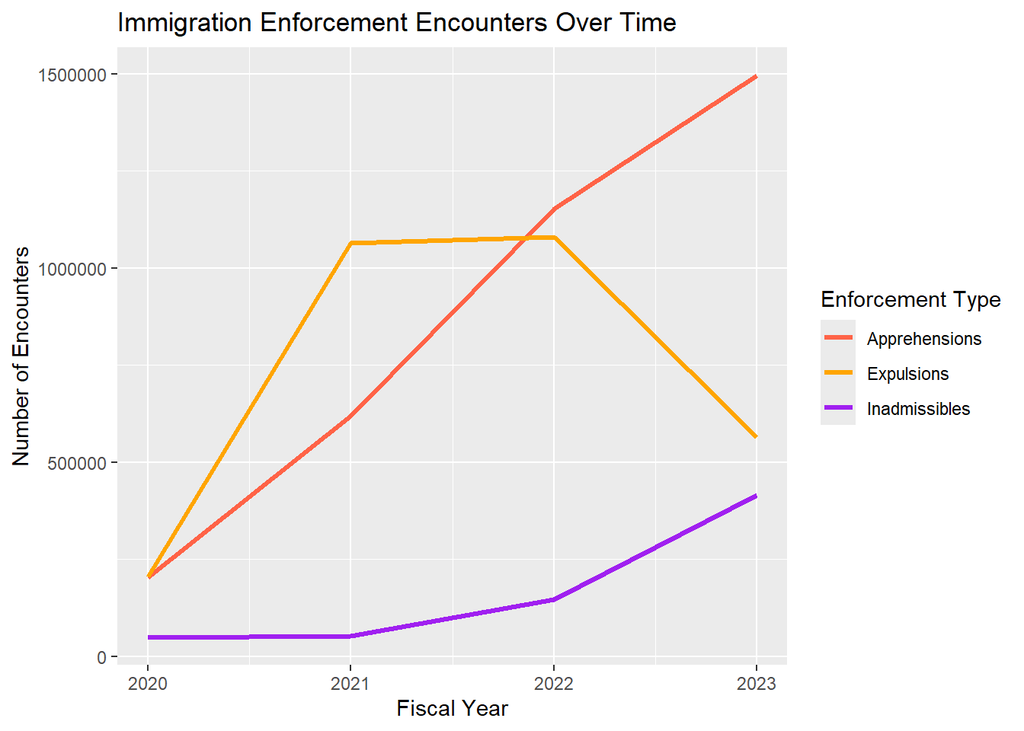

```r
app_long <- app_summary %>%
  pivot_longer(cols = c(Apprehensions, Expulsions, Inadmissibles),
               names_to = "Type", values_to = "Count")

ggplot(app_long, aes(x = Fiscal.Year, y = Count, color = Type)) +
  geom_line(size = 1.2) +
  labs(title = "Immigration Enforcement Encounters Over Time",
       x = "Fiscal Year", y = "Number of Encounters",
       color = "Enforcement Type") +
  scale_color_manual(values = c("Apprehensions" = "tomato",
                                "Expulsions" = "orange",
                                "Inadmissibles" = "purple"))
```

This line graph shows us the three different types of U.S Immigration enforcement action which include: Apprehensions, expulsions and inadmissible over the four fiscal years from 2020-2023. From the data, we can observe a rose in apprehension and has surpassed the rate of expulsion by 2022, which suggest a shift in enforcement strategy by the government. In additionaly, Inadmissble entris has also increased during this period, which indiccate a growing challenges at the broader for legal immigrant to enter.

### 6.3

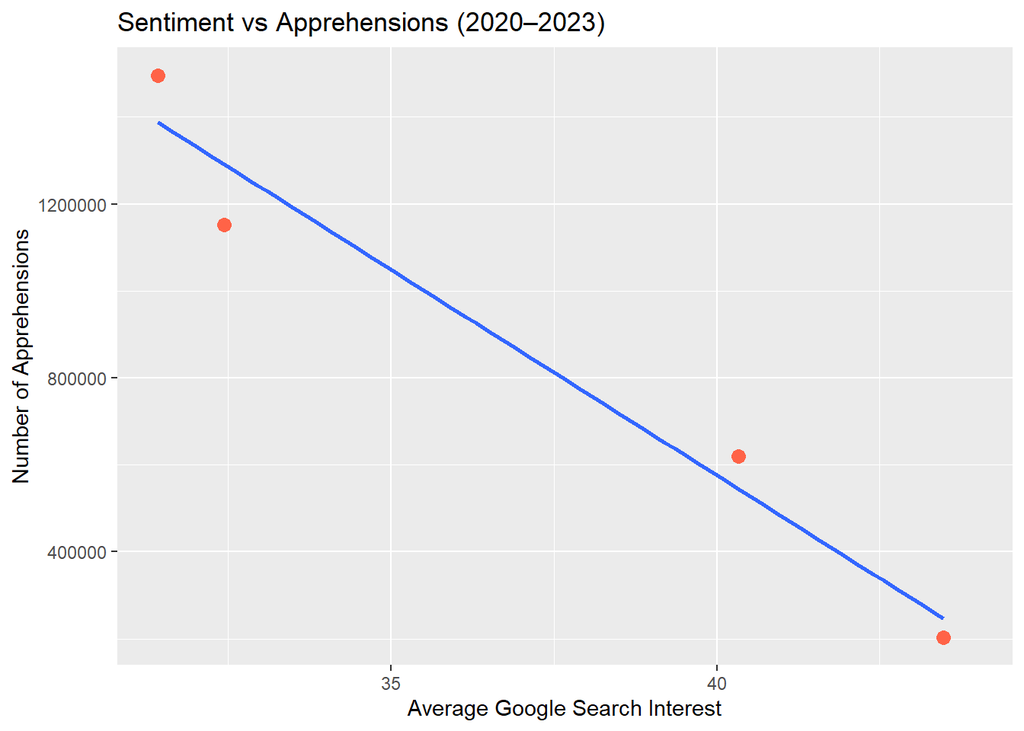

```r
ggplot(combined_df, aes(x = avg_query_incidence, y = Apprehensions)) +
  geom_point(color = "tomato", size = 3) +
  geom_smooth(method = "lm", se = FALSE) +
  labs(
    title = "Sentiment vs Apprehensions (2020–2023)",
    x = "Average Google Search Interest",
    y = "Number of Apprehensions"
  )
```

This scatter plot shows a clear negative correlation between average Google search interest in immigration and the number of apprehensions at the border. As public attention increases, enforcement activity appears to decline. This trend may suggest a lagged response in policy implementation or indicate that heightened public discourse influences shifts in enforcement priorities over time.

### 6.4 Additional Analysis with Google Trends

```r
google%>%
  group_by(daterange) %>%
  top_n(5,query_incidence)
```

```
## # A tibble: 68 × 5
## # Groups:   daterange [13]
##        X DMA                               daterange query_incidence Fiscal.Year
##    <int> <chr>                             <chr>               <int>       <dbl>
##  1     1 Yuma AZ-El Centro CA              04-08                 100        2008
##  2     2 Miami-Ft. Lauderdale FL           04-08                  84        2008
##  3     3 Harlingen-Weslaco-Brownsville-Mc… 04-08                  74        2008
##  4     4 Alpena MI                         04-08                  73        2008
##  5     5 Washington DC (Hagerstown MD)     04-08                  72        2008
##  6   211 Harlingen-Weslaco-Brownsville-Mc… 08-12                 100        2012
##  7   212 El Paso TX                        08-12                  92        2012
##  8   213 Laredo TX                         08-12                  85        2012
##  9   214 Miami-Ft. Lauderdale FL           08-12                  84        2012
## 10   215 New York NY                       08-12                  73        2012
## # ℹ 58 more rows
```

In additionly to the relationship between public sentiment and apprehension, it is also important to understand how the Google’s trend data is built by region in the United State which some states and city may have a higher interest in the topic of immigration. The data above has shows the the top 5 quiery incidence scores with each date range from 2004-2024. In the Google’s Trend data set, although some of the designated market area is listed as NA, however either the region or the city is provided.

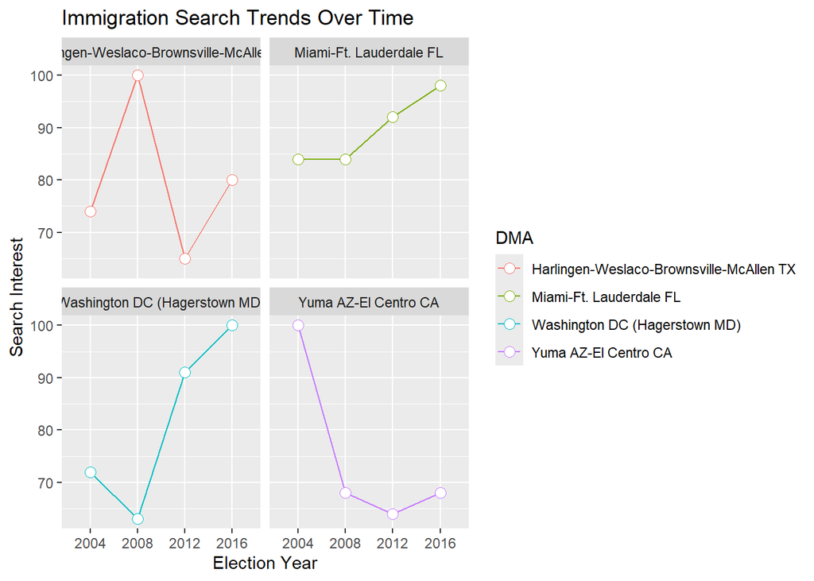

```r
election_data <- google %>%
  filter(DMA %in% c("Miami-Ft. Lauderdale FL", "Yuma AZ-El Centro CA",
                    "Harlingen-Weslaco-Brownsville-McAllen TX",
                    "Washington DC (Hagerstown MD)")) %>%
  filter(daterange %in% c("04-08", "08-12", "12-16", "16-20")) %>% # Filter for the desired date ranges
  mutate(election_year = case_when(
    daterange == "04-08" ~ "2004",
    daterange == "08-12" ~ "2008",
    daterange == "12-16" ~ "2012",
    daterange == "16-20" ~ "2016",
    TRUE ~ NA_character_
  ))

ggplot(election_data, aes(x = factor(election_year), y = query_incidence, color = DMA, group = DMA)) +
  geom_line() +
  geom_point(size = 3, shape = 21, fill = "white") +
  labs(title = "Immigration Search Trends Over Time", y = "Search Interest", x = "Election Year") +
  facet_wrap(~DMA)
```

## 7 Discussion

### 7.2. Limitations

Through out my research, I had notice some limitation about my research and analysis:

- Google Trends measures attention, but not opinion. A rise in search volume may indicate growing public interest in immigration, but it doesn’t tell us whether that interest is positive or negative.
- The data captures search behavior, but it does not direct public action and the effect may not be as strong as voting, protesting, or advocating for immigration reform.
- Regional Google Trends data is based on relative scores (0–100), not absolute search volume, which makes it difficult to compare true magnitude across locations.
- The possibility of Time Lag from the government’s enforcement may cause the result to become what we’re not expecting. For example, time lag may have switched a positive relationship between public sentiment and apprehension encoutners into a negative relationship.

### 7.3 Future Research

For my future research, I wish I could incorporate sentiment analysis from social media or news articles to capture actual actions, not just attention. In addition, I would like to expand the enforcement data set to include more years which would improve our longitudinal analysis.